# A Machine Learning Approach to Cation Identification for Solubility Optimization Of Redox Active Material for Non-aqueous Redox Flow Batteries

## Motivation

As renewable energy sources like wind and solar gain traction, efficient energy storage becomes crucial for grid stability. Redox flow batteries (RFBs) offer promising solutions, with non-aqueous RFBs (NRFBs) showing distinct advantages like wider temperature range and higher energy density.3 The solubility of active materials is a critical factor in determining the energy density of NRFBs. However, synthetically exploring a large parameter space to identify soluble species is an inefficient approach. To expedite NRFB material discovery and optimization, this work explores the transformative role of computation and machine learning.

## Methods Overview

- The surrogate model designed in this study was trained and tested using a dataset of 119 molecules for both [VBH]2- and [VBH]1- (total of 238 molecules), containing features related to molecular geometry

## Dependencies

The following dependencies were used for this study:

Scikit-learn : A free software machine learning library for the Python programming language.(see :https://scikit-learn.org/stable/)

RDKit : An open-source toolkit for cheminformatics (see: https://www.rdkit.org/)

NumPy : a library for the Python programming language, adding support for large, multi-dimensional arrays and matrices, along with a large collection of high-level mathematical functions to operate on these arrays (see: https://numpy.org/)

Matplotlib : a plotting library for the Python programming language and its numerical mathematics extension NumPy (see:https://matplotlib.org/)

Pandas : a software library written for the Python programming language for data manipulation and analysis (see:https://pandas.pydata.org/)

## Training Models

### Dependency Imports

```python
import numpy as np
import matplotlib.pyplot as plt
import rdkit
from rdkit import Chem
import pandas as pd
from sklearn.linear_model import LinearRegression
from sklearn.model_selection import train_test_split
from sklearn.linear_model import Ridge
from sklearn.ensemble import RandomForestRegressor
from sklearn.ensemble import ExtraTreesRegressor
from sklearn.tree import DecisionTreeRegressor
import seaborn as sns
from sklearn.metrics import r2_score
from sklearn import tree
from sklearn.metrics import mean_squared_error
import tensorflow as tf
from tensorflow import keras
from tensorflow.keras import Model, Sequential
from tensorflow.keras.optimizers import RMSprop
from tensorflow.keras.layers import Dense
from tensorflow.keras.losses import MeanSquaredError
```

### Data Import

```python
dataset_full = pd.read_csv("vbh_solubility_data.csv")

dataset_full.describe()
```

|  | Batch | Cat_Charge | Cat_MW | Cat_VdW | Cat_Rad_Gyr | Cat_Diameter | Cat_Len_x | Cat_Len_y | Cat_Len_z | Cat_MPP | ... | Latt_An_Hir_Vol | Latt_An_Hir_Area | Latt_An_Hir_Glob | Latt_An_Hir_Asph | V-N Dist (4) | dGsub | dGsol (MeCN) | dGdis (MeCN) | Log(So) | qed |
| --- | --- | --- | --- | --- | --- | --- | --- | --- | --- | --- | --- | --- | --- | --- | --- | --- | --- | --- | --- | --- | --- |
| count | 238.000000 | 238.0 | 238.000000 | 238.000000 | 238.000000 | 238.000000 | 238.000000 | 238.000000 | 238.000000 | 238.000000 | ... | 238.000000 | 238.000000 | 238.000000 | 238.000000 | 238.000000 | 238.000000 | 238.000000 | 238.000000 | 238.000000 | 238.000000 |
| mean | 1.932773 | 1.0 | 204.127076 | 243.442269 | 3.121185 | 13.108521 | 9.588412 | 9.303008 | 9.971647 | 1.094706 | ... | 306.538571 | 273.998950 | 0.802815 | 0.026345 | 6.213584 | 639.502731 | -749.208277 | -109.706050 | 19.537139 | 0.480208 |
| std | 0.632870 | 0.0 | 67.588817 | 81.975045 | 0.746327 | 2.629067 | 3.920567 | 3.394104 | 3.376480 | 0.191618 | ... | 23.594646 | 13.927159 | 0.018873 | 0.008040 | 0.647430 | 303.379324 | 314.500562 | 76.759387 | 13.375448 | 0.096629 |
| min | 1.000000 | 1.0 | 74.145000 | 93.940000 | 1.485000 | 6.631000 | 4.893000 | 5.520000 | 3.968000 | 0.328000 | ... | 193.640000 | 190.030000 | 0.690000 | 0.010000 | 4.644000 | 84.800000 | -1107.100000 | -691.150000 | 7.323300 | 0.109638 |
| 25% | 2.000000 | 1.0 | 144.278000 | 177.402500 | 2.602750 | 11.574000 | 6.307000 | 6.664250 | 7.008000 | 0.994250 | ... | 292.777500 | 266.577500 | 0.790000 | 0.020000 | 5.827500 | 361.835000 | -1060.577500 | -122.762500 | 12.385850 | 0.416541 |
| 50% | 2.000000 | 1.0 | 200.384000 | 243.890000 | 3.179000 | 14.018000 | 7.305000 | 7.319000 | 9.091000 | 1.101000 | ... | 301.645000 | 272.600000 | 0.800000 | 0.030000 | 6.221000 | 402.250000 | -741.750000 | -86.205000 | 15.433400 | 0.490049 |
| 75% | 2.000000 | 1.0 | 256.491000 | 310.250000 | 3.593500 | 14.305750 | 13.827000 | 12.887750 | 12.942000 | 1.205750 | ... | 311.352500 | 278.410000 | 0.810000 | 0.030000 | 6.685000 | 947.992500 | -434.825000 | -67.955000 | 21.697875 | 0.555501 |
| max | 3.000000 | 1.0 | 410.784000 | 496.020000 | 5.715000 | 21.659000 | 21.659000 | 21.658000 | 17.485000 | 1.676000 | ... | 411.580000 | 351.500000 | 0.850000 | 0.050000 | 7.590000 | 1067.180000 | -417.160000 | -39.920000 | 121.053500 | 0.641990 |

8 rows × 46 columns

### Feature Descriptions

```python
dataset_des = pd.read_csv("vbh_solubility_data_des.csv")
dataset_des
```

|  | Column Name | Description | Type |
| --- | --- | --- | --- |
| 0 | Code | Formula Unit | string |
| 1 | Batch | Batch number from when values were calculated | int |
| 2 | Cation | Code for the cation | string |
| 3 | Cat_SMILES | SMILES of cation | string |
| 4 | Cat_Charge | cation's charge | int |
| 5 | Cat_Formula | Molecular Formula of Cation | string |
| 6 | Cat_MW | Molecular Weight of Cation, amu | float |
| 7 | Cat_VdW | Total Van der Waals Volume of Cation (Multiwfn... | float |
| 8 | Cat_Rad_Gyr | Radius of Gyration of the Cation, Ang | float |
| 9 | Cat_Diameter | VdW diameter of the system, Ang | float |
| 10 | Cat_Len_x | Length of the system along x, Ang | float |
| 11 | Cat_Len_y | Length of the system along y, Ang | float |
| 12 | Cat_Len_z | Length of the system along z (Ang) | float |
| 13 | Cat_MPP | Molecular Planarity Parameter of Cation (MPP, ... | float |
| 14 | Cat_SDP | Span of Deviation from Plane (SDP,Multiwfn), Ang | float |
| 15 | Anion | Code for the anion | string |
| 16 | An_SMILES | SMILES for anion | string |
| 17 | An_Charge | Anion's charge | int |
| 18 | Anion_Ox_Num | Oxidation number of anion | int |
| 19 | An_Formula | Molecular Formula of Anion | string |
| 20 | An_MW | Molecular Weight of Anion, amu | float |
| 21 | An_VdW | Total Van der Waals Volume of Anion (Multiwfn)... | float |
| 22 | An_Rad_Gyr | Radius of Gyration of the Anion, Ang | float |
| 23 | An_Diameter | VdW diameter of the Anion, Ang | float |
| 24 | An_Len_x | Length of the system along x, Ang | float |
| 25 | An_Len_y | Length of the system along y, Ang | float |
| 26 | An_Len_z | Length of the system along z (Ang) | float |
| 27 | An_MPP | Molecular Planarity Parameter of Cation (MPP, ... | float |
| 28 | An_SDP | Span of Deviation from Plane (SDP,Multiwfn), Ang | float |
| 29 | Latt_MW | Total Molecular Weight of the crystal unit cel... | float |
| 30 | Latt_a | Lattice a parameter, Ang | float |
| 31 | Latt_b | Lattice b parameter, Ang | float |
| 32 | Latt_c | Lattice c parameter, Ang | float |
| 33 | Latt_alph | Lattice alpha parameter, deg. | float |
| 34 | Latt_beta | Lattice beta parameter, deg. | float |
| 35 | Latt_gam | Lattice gamma parameter, deg. | float |
| 36 | Latt_Vol | Lattice Volume, Ang^3 | float |
| 37 | Latt_Voids | Total volume of voids in the lattice, Ang^3 | float |
| 38 | Latt_SAV | Total Solvent Accessible Volume of the lattice... | float |
| 39 | Latt_Cat_Hir_Vol | Hirshfeld Volume of the Cation in the lattice,... | float |
| 40 | Latt_Cat_Hir_Area | Hirsheld Surface Area of the Cation in the lat... | float |
| 41 | Latt_Cat_Hir_Glob | Globularity index of the Hirshfeld Surface of ... | float |
| 42 | Latt_Cat_Hir_Asph | Asphericity index of the Hirshfeld Surface of ... | float |
| 43 | Latt_An_Hir_Vol | Hirshfeld Volume of the Anion in the lattice, ... | float |
| 44 | Latt_An_Hir_Area | Hirsheld Surface Area of the Anion in the latt... | float |
| 45 | Latt_An_Hir_Glob | Globularity index of the Hirshfeld Surface of ... | float |
| 46 | Latt_An_Hir_Asph | Asphericity index of the Hirshfeld Surface of ... | float |
| 47 | V-N Dist (4) | Average Vanadium (anion) and Nitrogen (cation)... | float |
| 48 | dGsub | Free Energy of Sublimation in kJ/mol | float |
| 49 | dGsol (MeCN) | Free Energy of Solvation in MeCN in kJ/mol | float |
| 50 | dGdis (MeCN) | Free Energy of dissolution in MeCN in kJ/mol | float |
| 51 | Log(So) | Solubility in Logarithmic scale | float |

### Extracting Cation Features

This study focuses on features related to the cation. For this purporse, all only the cation features, the target feature(Log(So), and anion oxidation number were kept (reasons discussed later)

```python
#Anion_Ox_Num for using in dataset seperation
dataset = dataset_full[["Cat_MW","Cat_VdW","Cat_Rad_Gyr","Cat_Diameter","Cat_Len_x","Cat_Len_y","Cat_Len_z","Cat_MPP",'Cat_SDP',"Anion_Ox_Num","Log(So)"]]
dataset
```

|  | Cat_MW | Cat_VdW | Cat_Rad_Gyr | Cat_Diameter | Cat_Len_x | Cat_Len_y | Cat_Len_z | Cat_MPP | Cat_SDP | Anion_Ox_Num | Log(So) |
| --- | --- | --- | --- | --- | --- | --- | --- | --- | --- | --- | --- |
| 0 | 74.145 | 93.94 | 1.485 | 6.631 | 6.044 | 6.032 | 5.605 | 1.115 | 3.123 | 4 | 7.4553 |
| 1 | 88.172 | 110.73 | 1.694 | 7.913 | 5.611 | 6.628 | 7.904 | 1.065 | 4.228 | 4 | 11.8260 |
| 2 | 102.198 | 127.62 | 2.014 | 9.214 | 5.905 | 6.627 | 9.091 | 1.026 | 4.227 | 4 | 11.1217 |
| 3 | 116.225 | 144.48 | 2.364 | 10.474 | 5.773 | 6.627 | 10.469 | 0.996 | 4.227 | 4 | 8.9096 |
| 4 | 102.198 | 127.35 | 1.914 | 9.085 | 5.508 | 6.622 | 9.085 | 1.026 | 4.222 | 4 | 12.4794 |
| ... | ... | ... | ... | ... | ... | ... | ... | ... | ... | ... | ... |
| 233 | 270.518 | 328.03 | 3.986 | 16.807 | 6.505 | 14.107 | 16.751 | 1.111 | 4.083 | 5 | 15.4321 |
| 234 | 284.544 | 345.62 | 4.291 | 17.596 | 7.305 | 14.080 | 17.485 | 1.269 | 4.926 | 5 | 17.6119 |
| 235 | 298.571 | 362.29 | 4.265 | 16.772 | 13.422 | 13.422 | 7.041 | 1.367 | 4.641 | 5 | 9.2088 |
| 236 | 354.677 | 428.75 | 4.985 | 19.157 | 19.157 | 19.157 | 7.055 | 1.322 | 4.655 | 5 | 7.7922 |
| 237 | 410.784 | 496.02 | 5.715 | 21.659 | 21.659 | 21.658 | 8.500 | 1.676 | 6.100 | 5 | 11.0622 |

238 rows × 11 columns

### Seperate Dataset For Different Anion Oxidation States

As discussed earlier, two sub-model systems were evaluated in this study (V+4: [cation]2[VBH]; V+5: [cation][VBH])

Machine learning models were built and used to explore new cations for both cases

### [VBH]2- V+4 sub dataset

```python
# sub dataset vbh2- V+4
df1 = dataset.loc[dataset['Anion_Ox_Num'] == 4].reset_index(drop = True).drop("Anion_Ox_Num",axis =1)
df1
```

|  | Cat_MW | Cat_VdW | Cat_Rad_Gyr | Cat_Diameter | Cat_Len_x | Cat_Len_y | Cat_Len_z | Cat_MPP | Cat_SDP | Log(So) |
| --- | --- | --- | --- | --- | --- | --- | --- | --- | --- | --- |
| 0 | 74.145 | 93.94 | 1.485 | 6.631 | 6.044 | 6.032 | 5.605 | 1.115 | 3.123 | 7.4553 |
| 1 | 88.172 | 110.73 | 1.694 | 7.913 | 5.611 | 6.628 | 7.904 | 1.065 | 4.228 | 11.8260 |
| 2 | 102.198 | 127.62 | 2.014 | 9.214 | 5.905 | 6.627 | 9.091 | 1.026 | 4.227 | 11.1217 |
| 3 | 116.225 | 144.48 | 2.364 | 10.474 | 5.773 | 6.627 | 10.469 | 0.996 | 4.227 | 8.9096 |
| 4 | 102.198 | 127.35 | 1.914 | 9.085 | 5.508 | 6.622 | 9.085 | 1.026 | 4.222 | 12.4794 |
| ... | ... | ... | ... | ... | ... | ... | ... | ... | ... | ... |
| 114 | 270.518 | 328.03 | 3.986 | 16.807 | 6.505 | 14.107 | 16.751 | 1.111 | 4.083 | 32.5508 |
| 115 | 284.544 | 345.62 | 4.291 | 17.596 | 7.305 | 14.080 | 17.485 | 1.269 | 4.926 | 29.4094 |
| 116 | 298.571 | 362.29 | 4.265 | 16.772 | 13.422 | 13.422 | 7.041 | 1.367 | 4.641 | 21.4749 |
| 117 | 354.677 | 428.75 | 4.985 | 19.157 | 19.157 | 19.157 | 7.055 | 1.322 | 4.655 | 8.9617 |
| 118 | 410.784 | 496.02 | 5.715 | 21.659 | 21.659 | 21.658 | 8.500 | 1.676 | 6.100 | 9.6865 |

119 rows × 10 columns

### [VBH]1- V+5 sub dataset

```python
# sub dataset vbh1- V+5
df2 = dataset.loc[dataset['Anion_Ox_Num'] == 5].reset_index(drop = True).drop("Anion_Ox_Num",axis =1)
df2
```

|  | Cat_MW | Cat_VdW | Cat_Rad_Gyr | Cat_Diameter | Cat_Len_x | Cat_Len_y | Cat_Len_z | Cat_MPP | Cat_SDP | Log(So) |
| --- | --- | --- | --- | --- | --- | --- | --- | --- | --- | --- |
| 0 | 266.247 | 222.85 | 2.911 | 13.957 | 13.946 | 7.445 | 6.909 | 0.986 | 4.524 | 13.1433 |
| 1 | 254.356 | 257.67 | 3.060 | 13.969 | 13.960 | 7.653 | 9.639 | 1.225 | 4.593 | 12.5078 |
| 2 | 254.356 | 257.87 | 2.996 | 13.794 | 13.785 | 8.269 | 7.354 | 1.137 | 4.767 | 15.1542 |
| 3 | 242.464 | 293.36 | 3.220 | 13.946 | 13.830 | 11.085 | 7.697 | 1.396 | 5.299 | 16.8702 |
| 4 | 242.464 | 292.30 | 3.139 | 13.771 | 13.770 | 10.405 | 7.757 | 1.464 | 5.341 | 15.3462 |
| ... | ... | ... | ... | ... | ... | ... | ... | ... | ... | ... |
| 114 | 270.518 | 328.03 | 3.986 | 16.807 | 6.505 | 14.107 | 16.751 | 1.111 | 4.083 | 15.4321 |
| 115 | 284.544 | 345.62 | 4.291 | 17.596 | 7.305 | 14.080 | 17.485 | 1.269 | 4.926 | 17.6119 |
| 116 | 298.571 | 362.29 | 4.265 | 16.772 | 13.422 | 13.422 | 7.041 | 1.367 | 4.641 | 9.2088 |
| 117 | 354.677 | 428.75 | 4.985 | 19.157 | 19.157 | 19.157 | 7.055 | 1.322 | 4.655 | 7.7922 |
| 118 | 410.784 | 496.02 | 5.715 | 21.659 | 21.659 | 21.658 | 8.500 | 1.676 | 6.100 | 11.0622 |

119 rows × 10 columns

### Feature selection

#### Correlation Analysis

Correlation analysis was used to select features to use for this study. Features with above a specified certain correlation coefficient with eachother (correlation threshold) were removed from the data. Finding a suitable correlation threshold was an iterative process which was dependent on model performance

#### Correlation Matrix before feature selection

##### [VBH]2-

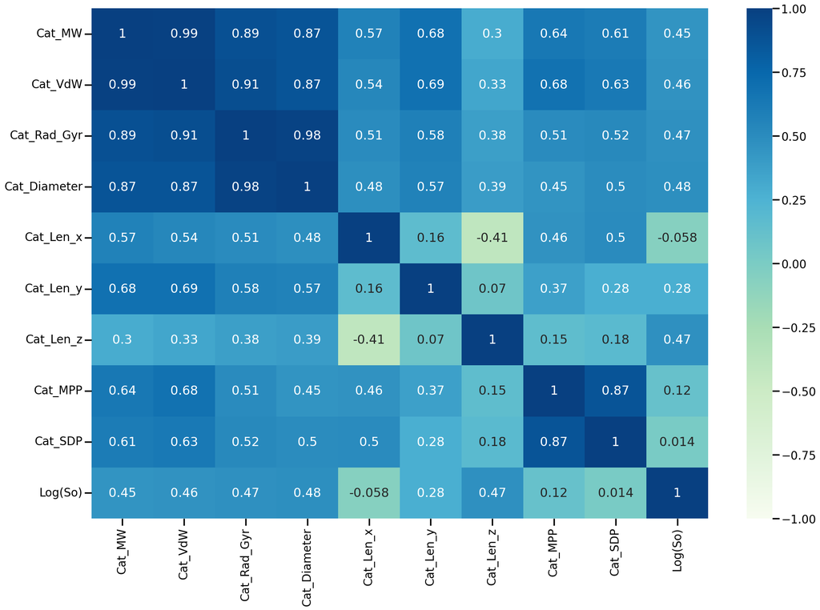

```python
def evaluate_correlation(dataset):
    plt.figure(figsize = (24, 16))
    corr = dataset.corr()
    with sns.plotting_context(context ="poster",font_scale=0.9):
        heatmap = sns.heatmap(corr,annot=True,cmap="GnBu",vmax=1,vmin=-1)
    plt.show()

evaluate_correlation(df1)
```

##### [vbh]1-

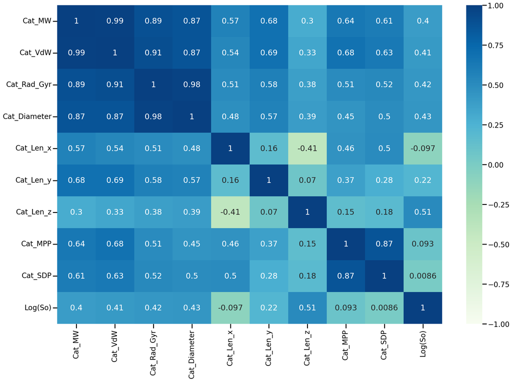

```python
evaluate_correlation(df2)
```

#### Correlation matrix after feature selection (threshold of 0.97)

##### [VBH]2-

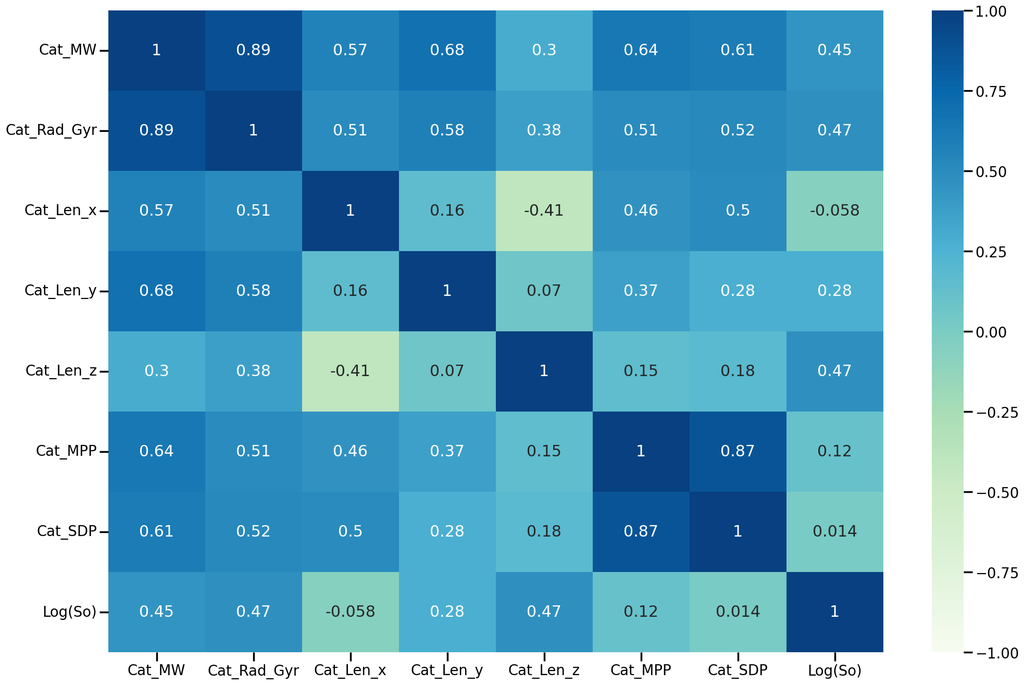

```python
# adjust dataset
def adjust_data(dataset):
    ''' filters out features with correlation coefficient >= 0.95 with each other'''

    # filter features with high correlation with each other
    upper_tri = dataset.corr().abs().where(np.triu (np.ones (dataset.corr().abs().shape), k=1).astype (bool))
    to_drop = [column for column in upper_tri.columns if any(upper_tri[column] >= 0.97)]
    dataset= dataset.drop (dataset [to_drop], axis=1)
    #test
    return dataset


adjusted_data1 = adjust_data(df1)
evaluate_correlation (adjusted_data1)
```

##### [VBH]1-

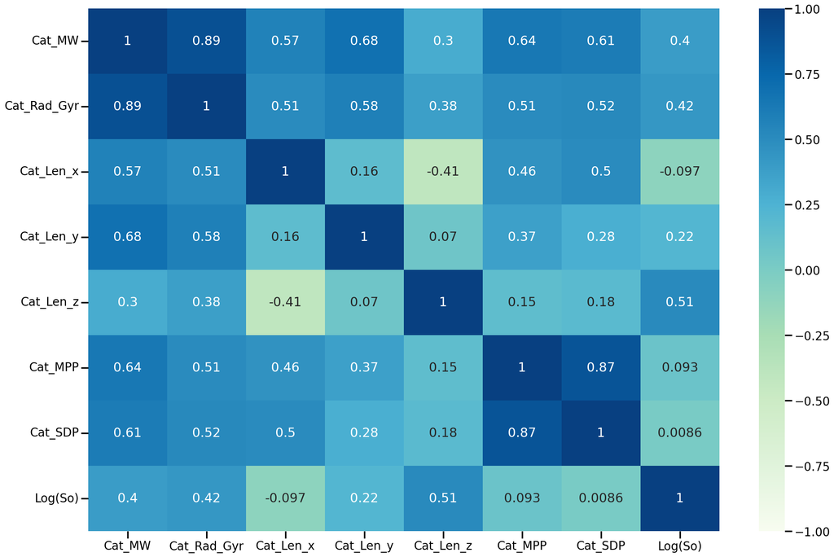

```python
adjusted_data2 = adjust_data(df2)
evaluate_correlation (adjusted_data2)
```

### Dataset split

For this study, 80% of the data (95 molecules) was used to train the models while 20% (24 molecules) was used to test models. This train- test split was selected as it produced the most accurate results, after implementing various other splits

##### [VBH]2-

```python
#dataset split

x1 = adjusted_data1.drop(["Log(So)"], axis = 1)
y1 = adjusted_data1["Log(So)"]


x_train1, x_test1, y_train1, y_test1 = train_test_split(x1, y1, test_size = 0.2, random_state = 1)
```

##### [VBH]1-

```python
#dataset split

x2 = adjusted_data2.drop(["Log(So)"], axis = 1)
y2 = adjusted_data2["Log(So)"]


x_train2, x_test2, y_train2, y_test2 = train_test_split(x2, y2, test_size = 0.2, random_state = 1)
```

### Evaluate model

The function below was uesd to evaluate the different regression models. The evaluation metrics used for this study were R-2 and RMSE metrics.. Cross plots were also created for each model. Cross plots, also known as scatter plots, are essential tools in machine learning for visually examining the relationship between two variables. They help identify correlations, patterns, and outliers, enabling data scientists to explore data, select relevant features, and interpret model predictions. By plotting one variable on the x-axis and another on the y-axis, cross plots provide valuable insights into data distribution and class separability in classification tasks. These simple yet powerful visualizations aid in understanding the data's characteristics, guiding feature selection, and facilitating informed decision-making throughout the machine learning process.

```python
#score models

def score_model(model,x_train,x_test,y_train,y_test,show= False):
    '''
    Returns R-2 and RMSE values on test and train set for input model as a list. This function outputs a crossplot if show parameter is set to True
    '''
    # predict data
    pred_test = model.predict(x_test)
    pred_train = model.predict(x_train)


    #score predictions with r2 and rmse
    score_list = []
    train_r2 = r2_score(y_train, pred_train)
    test_r2 = r2_score(y_test, pred_test)
    train_rmse = mean_squared_error(y_train, pred_train, squared = False)
    test_rmse = mean_squared_error(y_test, pred_test, squared = False)

    score_list.extend((train_r2, test_r2, train_rmse, test_rmse))

    # visualize metrics
    if(show):
        # print scores
        print("Trian set R-sqaure  : ", r2_score(y_train, pred_train))
        print("Test set R-square : ", r2_score(y_test, pred_test))
        print("RMSE on training set : ", np.sqrt(mean_squared_error(y_train, pred_train)))
        print("RMSE on test set : ", np.sqrt(mean_squared_error(y_test, pred_test)))

        # visualize prediciton
        plt.figure()
        plt.scatter(y_train, pred_train,color="blue", alpha=0.8, label="train")
        plt.scatter(y_test, pred_test, color="red", alpha=0.8, label="test")
        p1 = max(max(pred_train), max(y_train))
        p2 = min(min(pred_train), min(y_train))
        plt.plot([p1, p2], [p1, p2], 'k-')
        plt.xlabel("actual Log(So)")
        plt.ylabel("predicted Log(So)")
        plt.legend(loc = 'best')
        plt.show

    else :
        return score_list
```

### Ranking features by importance

The function below was used to create a plot of the different features ranked by thier feature importancee for tree-based models

```python
def plot_feature_importance(model):
    #Create arrays from feature importance and feature names
    feature_importance = np.array(model.feature_importances_,)
    feature_names = np.array(x_train1.columns)

    #Create a DataFrame using a Dictionary
    data={'feature_names':feature_names,'feature_importance':feature_importance}
    fi_df = pd.DataFrame(data)
    my_range=range(1,len(fi_df.index)+1)

    #Sort the DataFrame in order decreasing feature importance
    fi_df.sort_values(by=['feature_importance'], ascending=True,inplace=True)

    # The horizontal plot is made using the hline function
    plt.hlines(y=my_range, xmin=0, xmax=fi_df['feature_importance'], color='skyblue')
    plt.plot(fi_df['feature_importance'], my_range, "o")

    # Add titles and axis names
    plt.yticks(my_range, fi_df['feature_names'])
    plt.xlabel('Feature Importance')
    plt.ylabel('Features')

    # Show the plot
    plt.show()
```

## Regression Models

### Linear Regression

##### [VBH]2-

```
Trian set R-sqaure  :  0.4289323392845581
Test set R-square :  0.5816066864164415
RMSE on training set :  11.725983336357618
RMSE on test set :  11.784635098614777
```

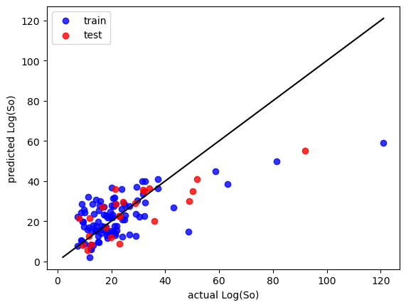

```python
LR1 = LinearRegression().fit(x_train1,y_train1)
LR_score1 = score_model(LR1,x_train1, x_test1, y_train1, y_test1, show= True)
```

##### [VBH]1-

```
Trian set R-sqaure  :  0.387026369624334
Test set R-square :  0.5334047225480274
RMSE on training set :  6.001080239394219
RMSE on test set :  6.541838002611203
```

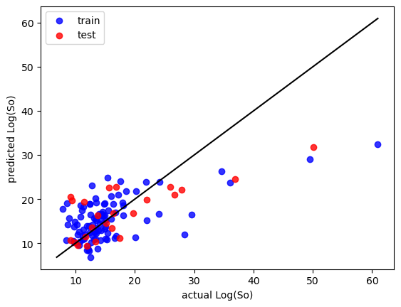

```python
LR2 = LinearRegression().fit(x_train2,y_train2)
LR_score2 = score_model(LR2,x_train2, x_test2, y_train2, y_test2, show= True)
```

### ExtraTrees Regressor

##### [VBH]2-

```
Trian set R-sqaure  :  0.9999197283075285
Test set R-square :  0.6586017876340027
RMSE on training set :  0.1390230138085815
RMSE on test set :  10.645213919653274
```

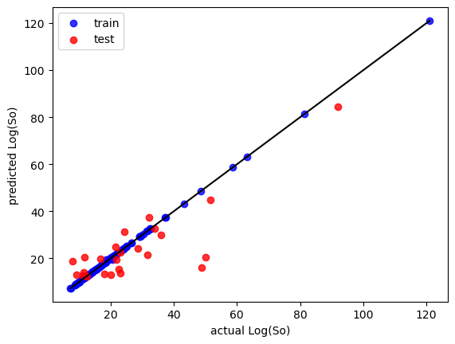

```python
ET1 = ExtraTreesRegressor(n_estimators=1000, random_state=1).fit(x_train1, y_train1)
ET1_score = score_model(ET1, x_train1, x_test1, y_train1, y_test1, show = True)
```

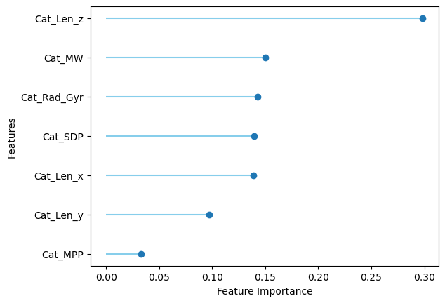

```python
plot_feature_importance(ET1)
```

##### [VBH]1-

```
Trian set R-sqaure  :  0.999984992345849
Test set R-square :  0.7151917488380117
RMSE on training set :  0.029693742917002778
RMSE on test set :  5.111000217873582
```

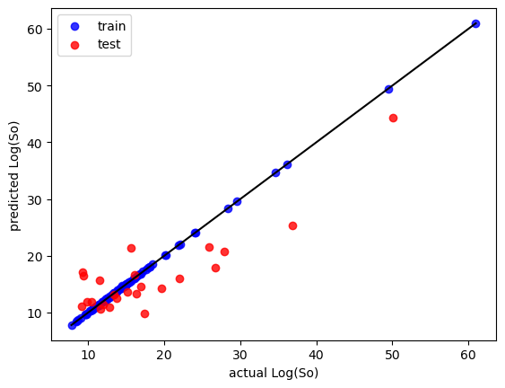

```python
ET2 = ExtraTreesRegressor(n_estimators=1000, random_state=1).fit(x_train2, y_train2)
ET2_score = score_model(ET2, x_train2, x_test2, y_train2, y_test2, show = True)
```

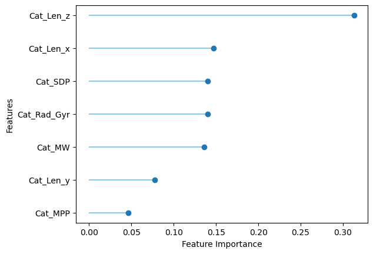

```python
plot_feature_importance(ET2)
```

### Random Forest

##### [VBH]2-

```
Trian set R-sqaure  :  0.915731938768762
Test set R-square :  0.6988022695294862
RMSE on training set :  4.504400419720511
RMSE on test set :  9.998840010542223
```

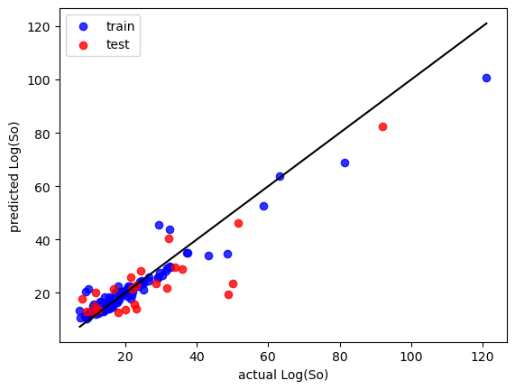

```python
RF1 = RandomForestRegressor().fit(x_train1,y_train1)
RF1_score = score_model(RF1, x_train1, x_test1, y_train1, y_test1, show = True)
```

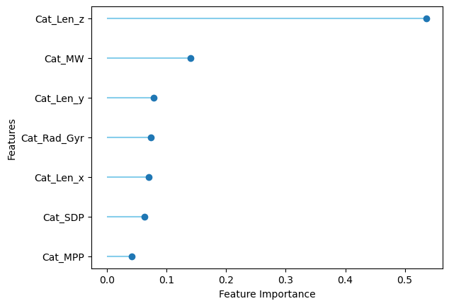

```python
plot_feature_importance(RF1)
```

##### [VBH]1-

```
Trian set R-sqaure  :  0.9133890611416046
Test set R-square :  0.6184568475417425
RMSE on training set :  2.255770489896984
RMSE on test set :  5.915636062330978
```

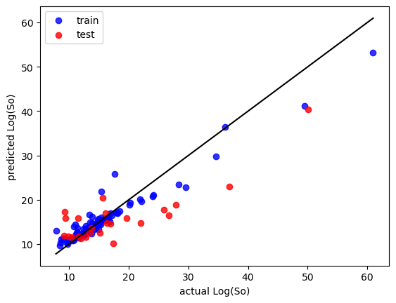

```python
RF2 = RandomForestRegressor().fit(x_train2,y_train2)
RF2_score = score_model(RF2, x_train2, x_test2, y_train2, y_test2, show = True)
```

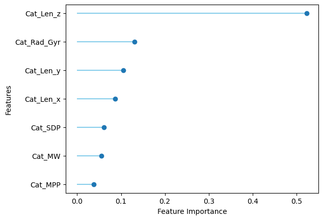

```python
plot_feature_importance(RF2)
```

### Boosting Algorithms

Boosting is a popular ensemble learning technique in machine learning that sequentially builds multiple weak learners to create a strong learner. Each weak learner focuses on correcting the errors made by its predecessors, effectively improving the overall model's performance. The most common boosting algorithms include AdaBoost, Gradient Boosting, and XGBoost, each with its variations and strengths. Boosting iteratively gives higher weights to misclassified data points, allowing subsequent weak learners to focus on these challenging cases. As a result, the ensemble becomes more robust and accurate, even with complex datasets and noisy features. Boosting has become a widely used approach due to its ability to handle various types of data and provide highly accurate predictions. However, it can be sensitive to outliers and might require careful tuning to avoid overfitting. In summary, boosting is a powerful ensemble technique that iteratively improves the model's accuracy by combining multiple weak learners. It has proven to be effective in a wide range of machine learning tasks, making it a popular choice for predictive modeling.

### XGBoost

##### [VBH]2-

```
Trian set R-sqaure  :  0.9999192557170592
Test set R-square :  0.5903457035419435
RMSE on training set :  0.13943165433441454
RMSE on test set :  11.660912293730696
```

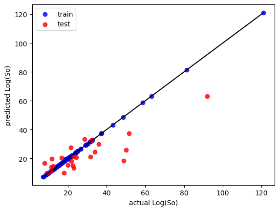

```python
import xgboost as xgb

XGB1 = xgb.XGBRegressor(n_estimators=4000, max_depth=7, eta=0.3, subsample=0.7, colsample_bytree=0.7).fit(x_train1,y_train1)
XGB1_score = score_model(XGB1,x_train1, x_test1, y_train1, y_test1, show = True)
```

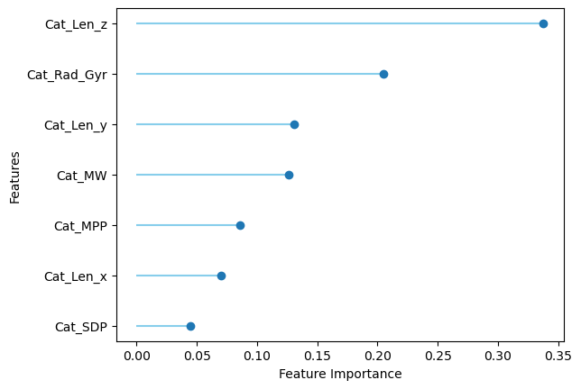

```python
plot_feature_importance(XGB1)
```

##### [VBH]1-

```
Trian set R-sqaure  :  0.9999842635378469
Test set R-square :  0.5847399535385494
RMSE on training set :  0.03040619584940499
RMSE on test set :  6.171485174524401
```

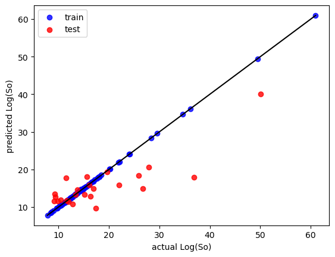

```python
XGB2 = xgb.XGBRegressor(n_estimators=4000, max_depth=8, eta=0.2, subsample=0.8, colsample_bytree=0.8).fit(x_train2,y_train2)
XGB2_score = score_model(XGB2,x_train2, x_test2, y_train2, y_test2, show = True)
```

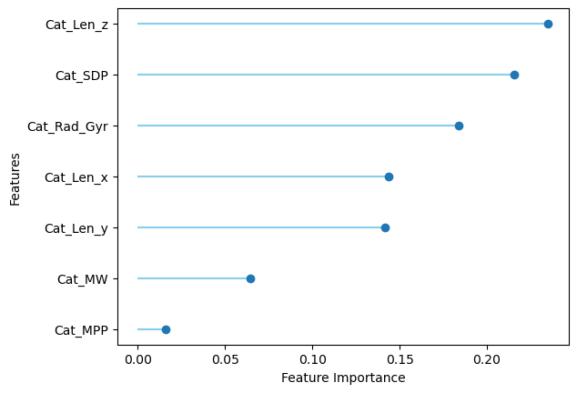

```python
plot_feature_importance(XGB2)
```

### Cat Boost

##### [VBH]2-

```
Trian set R-sqaure  :  0.888149832626202
Test set R-square :  0.7327094426610867
RMSE on training set :  5.189479591434482
RMSE on test set :  9.41923386942424
```

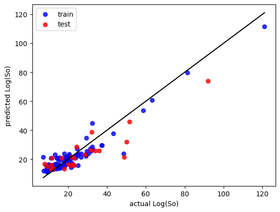

```python
from catboost import CatBoostRegressor, Pool

pool_train1 = Pool(x_train1, y_train1,)

pool_test1 = Pool(x_test1)

CBR1 = CatBoostRegressor(iterations=10000,max_depth=2,learning_rate=0.001).fit(pool_train1,logging_level='Silent')

CBR1_score = score_model(CBR1,x_train1, x_test1, y_train1, y_test1, show = True)
```

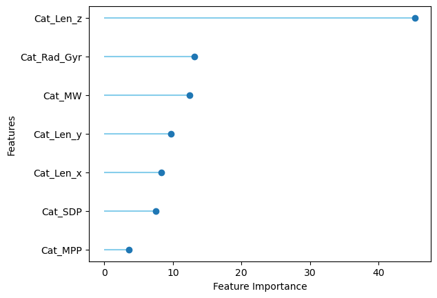

```python
plot_feature_importance(CBR1)
```

##### [VBH]1-

```
Trian set R-sqaure  :  0.9504074195166637
Test set R-square :  0.7304893260882614
RMSE on training set :  1.7069346368518146
RMSE on test set :  4.971845230397082
```

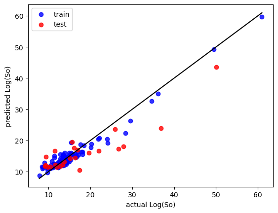

```python
pool_train2 = Pool(x_train2, y_train2)

pool_test2 = Pool(x_test2)

CBR2 = CatBoostRegressor(iterations=10000,max_depth=2,learning_rate=0.002).fit(pool_train2,logging_level='Silent')
CBR1_score = score_model(CBR2,x_train2, x_test2, y_train2, y_test2, show = True)
```

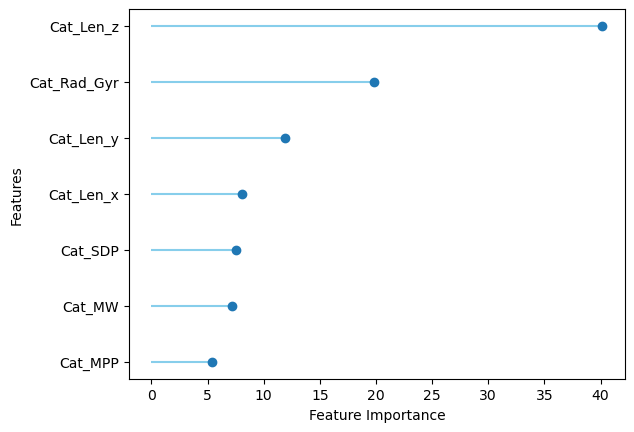

```python
plot_feature_importance(CBR2)
```

### Adaptive Boost

AdaBoost is an ensemble learning algorithm that combines weak learners to improve accuracy. It assigns higher weights to misclassified data and iteratively updates them, leading to a more accurate model. Effective in binary classification tasks, AdaBoost is widely used in face detection, object recognition, and bioinformatics. Its ability to leverage weak learners effectively makes it a valuable tool in machine learning.

##### [VBH]2-

```
Trian set R-sqaure  :  0.8828633519270241
Test set R-square :  0.7318259026151374
RMSE on training set :  5.3107014234826115
RMSE on test set :  9.434788860122968
```

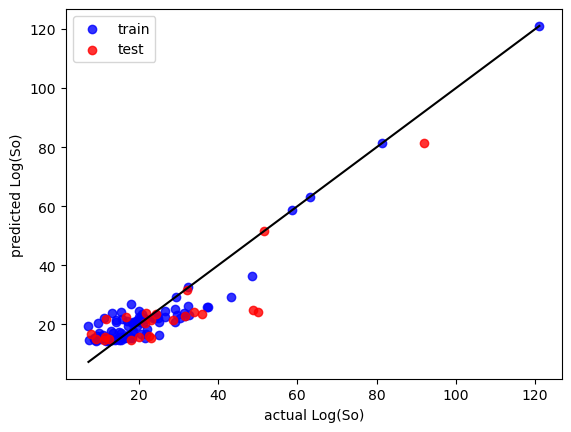

```python
from sklearn.ensemble import AdaBoostRegressor
AB1 = AdaBoostRegressor(n_estimators= 2000, learning_rate= 0.01, random_state=1).fit(x_train1,y_train1)

AB1_score = score_model(AB1,x_train1, x_test1, y_train1, y_test1, show = True)
```

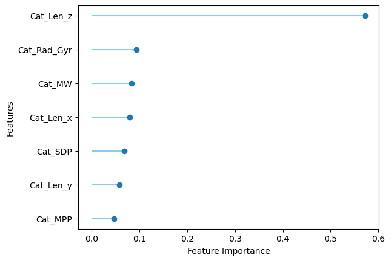

```python
plot_feature_importance(AB1)
```

##### [VBH]1-

```
Trian set R-sqaure  :  0.8994216258175114
Test set R-square :  0.7135389655332365
RMSE on training set :  2.4308650148007844
RMSE on test set :  5.125808700234961
```

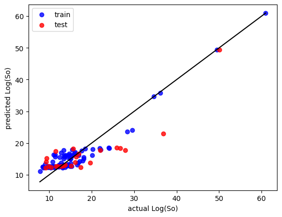

```python
AB2 = AdaBoostRegressor(n_estimators= 5000, learning_rate= 0.01, random_state=2).fit(x_train2,y_train2)

AB2_score = score_model(AB2,x_train2, x_test2, y_train2, y_test2, show = True)
```

### Redisual Comparison for Different Models

Residual distribution plots are graphical representations of the differences between actual and predicted values in regression models. They help evaluate the model's performance and assumptions by examining patterns in the residuals' distribution. A well-behaved residual plot shows a mean close to zero, consistent spread of residuals across predictions (homoscedasticity), and independence of residuals. Deviations from these patterns can indicate issues like bias, non-linearity, or outliers, prompting data scientists to improve the model iteratively. In summary, residual distribution plots offer valuable insights into model accuracy and guide refinements for better predictive performance in machine learning tasks.

```python
def resplot(models,label,x_test,y_test):
    model_names = ["AdaBoost","RandomForest","XGBoost","CatBoost","DecisionTree","LinearRegression","ExtraTrees"]
    residuals = []
    mods=[]

    for model in models:
        res = y_test - model.predict(x_test)

        for i in res:
            residuals.append(i)
            mods.append(model_names[models.index(model)])

    d = pd.DataFrame(data={'models': mods, 'residuals': residuals})


    displot = sns.displot(data=d, x="residuals", hue="models", kind="kde",height=5, aspect=1).fig.suptitle(label,fontsize=14)
    plt.show()
```

##### [VBH]2-

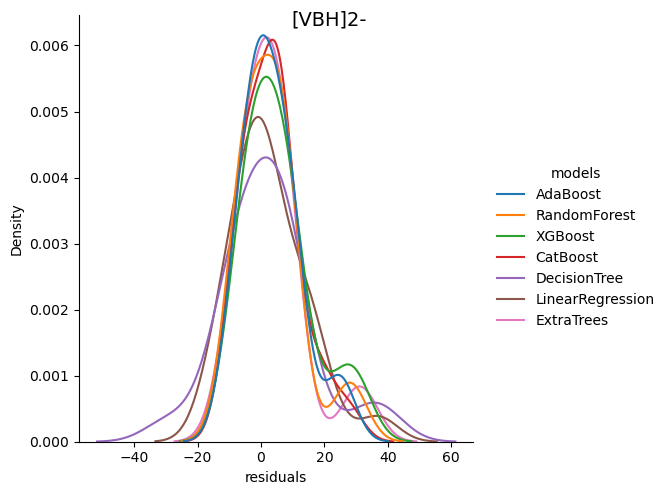

```python
models1 = [AB1,RF1,XGB1,CBR1,DT1,LR1,ET1]

resplot(models1,"[VBH]2-",x_test1,y_test1)
```

[output not shown]

[output not shown]

##### [VBH]1-

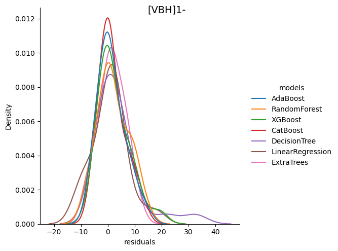

```python
models2 = [AB2,RF2,XGB2,CBR2,DT2,LR2,ET2]

resplot(models2,"[VBH]1-",x_test2,y_test2)
```

## Predicting Solubility for New Cation Molecules

### Import Data

```python
new_data = pd.read_csv("Explored_ChemBL_Cations.csv")
new_data
```

|  | Cat_SMILES | Cat_MW | Cat_Rad_Gyr | Cat_Len_x | Cat_Len_y | Cat_Len_z | Cat_MPP | Cat_SDP |
| --- | --- | --- | --- | --- | --- | --- | --- | --- |
| 0 | C[N+]1(CCCF)C2CCC1CC(OC(=O)C(O)(c1ccccc1)c1ccc... | 412.517882 | 4.184433 | 16.265 | 7.327 | 11.336 | 1.258957 | 5.160535 |
| 1 | Cc1cc2c3ccccc3[n+]1CCCCCCCCCC[n+]1c(C)cc(c3ccc... | 594.916812 | 5.763401 | 19.226 | 12.784 | 8.616 | 1.227331 | 6.117464 |
| 2 | C[N+]1(C)[C@@H]2C[C@@H](OC3c4ccccc4CSc4ccccc43... | 380.523686 | 3.777694 | 11.007 | 13.597 | 7.896 | 1.369160 | 5.637441 |
| 3 | C[N+](C)(C)CCOC(=O)C1CCC[N+]1(C)C | 230.347507 | 3.433438 | 6.463 | 7.224 | 13.387 | 1.128212 | 4.050765 |
| 4 | COc1ccc2cc1Oc1cc3c(cc1OC)CC[N+](C)(C)[C@H]3Cc1... | 652.820428 | 4.878874 | 13.642 | 16.545 | 9.153 | 1.502029 | 6.843417 |
| ... | ... | ... | ... | ... | ... | ... | ... | ... |
| 535 | CO[C@H]1C[C@@H]2C[C@H](OC(=O)C(O)(c3ccccc3)c3c... | 396.500207 | 3.753061 | 8.500 | 14.195 | 10.957 | 1.657406 | 6.210055 |
| 536 | Cc1cc(-c2ccccc2)n[n+](CCCC(=O)O)c1N | 272.322892 | 3.682648 | 9.610 | 15.248 | 5.958 | 0.768892 | 3.639789 |
| 537 | C[N+]1(Cc2ccc(-c3ccccc3)cc2)[C@@H]2CC[C@H]1C[C... | 456.596981 | 5.531420 | 8.871 | 21.143 | 10.027 | 1.431970 | 6.528289 |
| 538 | C[N+]12CCC(CC1)C(OCC(O)(c1ccccc1)C1CCCC1)C2 | 330.485071 | 3.725320 | 11.788 | 6.944 | 13.510 | 1.214515 | 4.543244 |
| 539 | CCC[N+]1(C)[C@@H]2CC[C@H]1CC(OC1c3ccccc3CSc3cc... | 394.593397 | 3.848593 | 11.252 | 7.840 | 14.588 | 1.326619 | 5.199113 |

540 rows × 8 columns

### Generate predictions for each model

```python
def pred_LogSo(model,data):
    ''' returns dataframe and solubility predictions
    '''
    smiles = [smi for smi in data["Cat_SMILES"]]
    LogSo = [LogSo for LogSo in model.predict(new_data.drop("Cat_SMILES",axis =1))]

    d = {'Cat_SMILES': smiles, 'Log(So)': LogSo}
    return pd.DataFrame(data=d)
```

```python
# use RDKIt to draw grid on molecules and solubility for top 15 molecules
def show_best(data):

    best_mol = data.sort_values(by=['Log(So)'],ascending= False).head(15).reset_index(drop = True)

    mols  = [Chem.MolFromSmiles(smi) for smi in best_mol["Cat_SMILES"] ]


    return rdkit.Chem.Draw.MolsToGridImage([m for m in mols if m is not None], molsPerRow=5, subImgSize=(300, 200),legends=[str(round(x, 4)) for x in best_mol["Log(So)"]])
```

### [VBH]2-

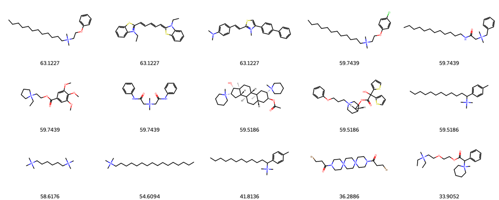

```python
#AdaBoost
show_best(pred_LogSo(AB1,new_data))
```

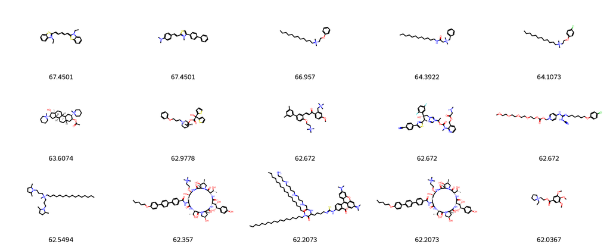

```python
#RandomForest
show_best(pred_LogSo(RF1,new_data))
```

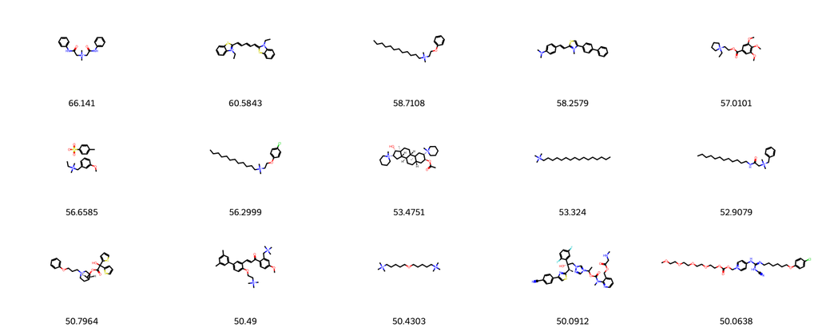

```python
#CatBoost
show_best(pred_LogSo(CBR1,new_data))
```

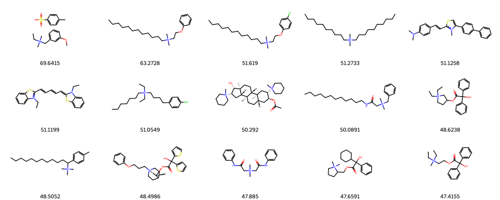

```python
#XGBoost
show_best(pred_LogSo(XGB1,new_data))
```